# Results and Operationalization

Andrew Nguyen

December 13, 2019

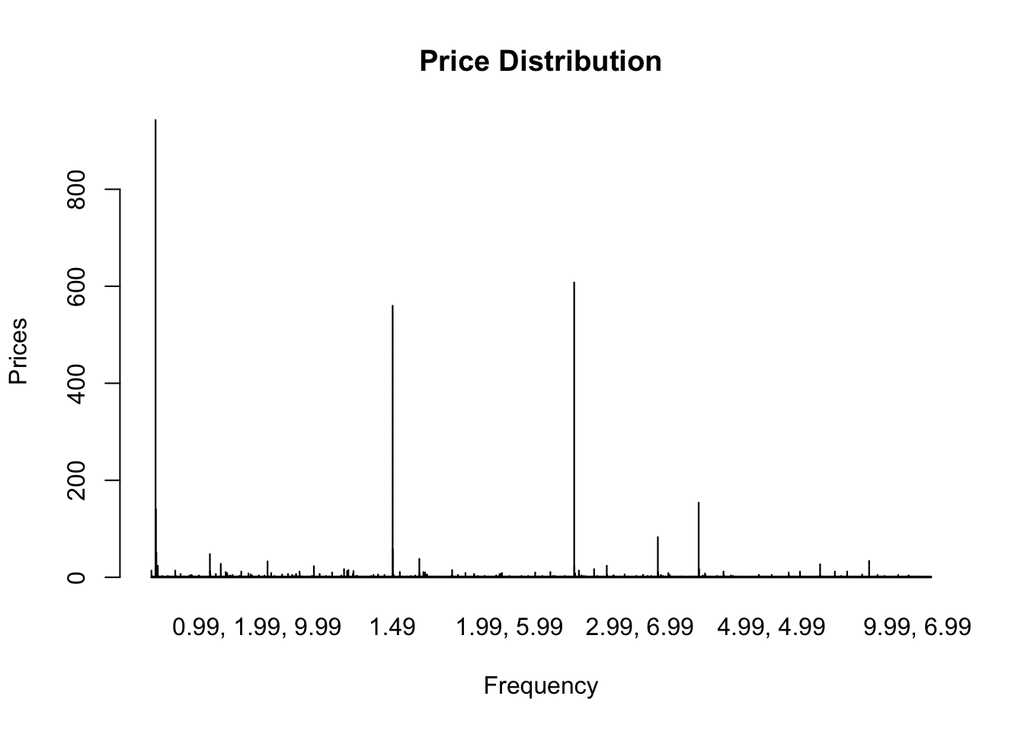

# Introduction

In this deliverable, the goal is to refine things done in previous work and make concluding statements on the overall portfolio project, including operationalization, social impacts, and unintented consequences of the study. Much of my refinery changes are due to suggestions and peer reviews made by others; in particular, many thanks to [kippyan’s review summary](https://github.com/anguyen62/anguyen62.github.io/issues/4). My portfolio seemed mostly organized, leaving revisions mostly including supressing output from several code blocks where the output is not needed; an egregious issue especially in deliverable 2. One suggestion that I believe is effective but could not be implemented on my own skill was refining the price distribution graph; prices could be sorted and grouped together instead of scattered on the X-axes, and the axes can be switched entirely. The Size and Ratings Relationship Graph could have also better illustrated my intended points.

For reference, here are the updated deliverables: [Deliverable 1](https://anguyen62.github.io/DataScience/deliverable1.html) | [Deliverable 2](https://anguyen62.github.io/DataScience/deliverable2.html)

# Data

All data was processed to be as tidy as possible. A head of most of the data tables (that are not the initialized, pre-cleaned forms) are as shown:

```r
head(GameData)
```

|  | URL | ID | Name | Subtitle | App Icon URL | Average User Rating | Total Ratings | Price | In-App Purchases | Description | Developer | Age Rating | Languages | Size | Primary Genre | Game Genres | Original Release Date | Current Version Release Date |
| --- | --- | --- | --- | --- | --- | --- | --- | --- | --- | --- | --- | --- | --- | --- | --- | --- | --- | --- |
| 1 | https://apps.apple.com/us/app/sudoku/id284921427 | 284921427 | Sudoku |  | https://is2-ssl.mzstatic.com/image/thumb/Purple127/v4/7d/23/c6/7d23c660-aba8-308a-05c0-19385a377c0e/source/512x512bb.jpg | 4.0 | 3553 | 2.99 |  | Join over 21,000,000 of our fans and download one of our Sudoku games today!\\n\\nMakers of the Best Sudoku Game of 2008, Sudoku (Free), we offer you the best selling Sudoku game for iPhone with great… | Mighty Mighty Good Games | 4+ | DA, NL, EN, FI, FR, DE, IT, JA, KO, NB, PL, PT, RU, ZH, ES, SV, ZH | 15853568 | Games | Games, Strategy, Puzzle | 11/7/08 | 30/05/2017 |
| 2 | https://apps.apple.com/us/app/reversi/id284926400 | 284926400 | Reversi |  | https://is4-ssl.mzstatic.com/image/thumb/Purple128/v4/f7/e8/10/f7e810c8-72b4-cd85-e2d3-fbcb1e3ef381/source/512x512bb.jpg | 3.5 | 284 | 1.99 |  | The classic game of Reversi, also known as Othello, is a much-loved strategy board game. It is often described as taking only a minute to learn but a lifetime to master. Each game only takes a few min… | Kiss The Machine | 4+ | EN | 12328960 | Games | Games, Strategy, Board | 11/7/08 | 17/05/2018 |
| 3 | https://apps.apple.com/us/app/morocco/id284946595 | 284946595 | Morocco |  | https://is5-ssl.mzstatic.com/image/thumb/Purple118/v4/98/b2/41/98b241cc-29b7-5f67-0060-1e030f35562f/source/512x512bb.jpg | 3.0 | 8376 | 0.00 |  | Play the classic strategy game Othello (also known as Reversi) on your iPhone or iPod Touch. The object is to finish the game with more of your pieces on the board than your opponent.\\n\\nFEATURES\\n… | Bayou Games | 4+ | EN | 674816 | Games | Games, Board, Strategy | 11/7/08 | 5/9/17 |
| 4 | https://apps.apple.com/us/app/sudoku-free/id285755462 | 285755462 | Sudoku (Free) |  | https://is3-ssl.mzstatic.com/image/thumb/Purple117/v4/64/da/aa/64daaaa4-40b5-9e9f-9d60-b936b5d2f3ca/source/512x512bb.jpg | 3.5 | 190394 | 0.00 |  | Top 100 free app for over a year.\\nRated "Best Sudoku Game of the Year" by Apple.\\nRated #9 Game of the Year by Apple.\\nRated #24 App of the Year by Apple with over 10,000 apps competing!\\n\\nWith… | Mighty Mighty Good Games | 4+ | DA, NL, EN, FI, FR, DE, IT, JA, KO, NB, PL, PT, RU, ZH, ES, SV, ZH | 21552128 | Games | Games, Strategy, Puzzle | 23/07/2008 | 30/05/2017 |
| 5 | https://apps.apple.com/us/app/senet-deluxe/id285831220 | 285831220 | Senet Deluxe |  | https://is1-ssl.mzstatic.com/image/thumb/Purple118/v4/ab/2d/cf/ab2dcfe6-2178-6f74-2d42-0b6db66fc7e0/source/512x512bb.jpg | 3.5 | 28 | 2.99 |  | "Senet Deluxe - The Ancient Game of Life and Afterlife\\n\\nSenet is an ancient Egyptian race game and the predecessor of our modern Backgammon. The oldest known form of the game is shown in a paintin… | RoGame Software | 4+ | DA, NL, EN, FR, DE, EL, IT, JA, KO, NO, PT, RU, ZH, ES, SV | 34689024 | Games | Games, Strategy, Board, Education | 18/07/2008 | 22/07/2018 |
| 6 | https://apps.apple.com/us/app/sudoku-classic-number-puzzle/id286210009 | 286210009 | Sudoku - Classic number puzzle | Original brain training | https://is1-ssl.mzstatic.com/image/thumb/Purple123/v4/69/92/8a/69928a8c-fbb4-a973-8e19-75dabba0c6a1/source/512x512bb.jpg | 3.0 | 47 | 0.00 | 1.99 | Sudoku will tease your brain, challenge you or allow you to unwind and relax. With the easiest interface, it will give you the perfect Sudoku experience. Big numbers, a straight-forward toolbar for th… | OutOfTheBit Ltd | 4+ | EN | 48672768 | Games | Games, Entertainment, Strategy, Puzzle | 30/07/2008 | 29/04/2019 |

```r
head(gameswithpurchases)
```

|  | URL | ID | Name | Subtitle | App Icon URL | Average User Rating | Total Ratings | Price | In-App Purchases | Description | Developer | Age Rating | Languages | Size | Primary Genre | Game Genres | Original Release Date | Current Version Release Date |
| --- | --- | --- | --- | --- | --- | --- | --- | --- | --- | --- | --- | --- | --- | --- | --- | --- | --- | --- |
| 6 | https://apps.apple.com/us/app/sudoku-classic-number-puzzle/id286210009 | 286210009 | Sudoku - Classic number puzzle | Original brain training | https://is1-ssl.mzstatic.com/image/thumb/Purple123/v4/69/92/8a/69928a8c-fbb4-a973-8e19-75dabba0c6a1/source/512x512bb.jpg | 3.0 | 47 | 0.00 | 1.99 | Sudoku will tease your brain, challenge you or allow you to unwind and relax. With the easiest interface, it will give you the perfect Sudoku experience. Big numbers, a straight-forward toolbar for th… | OutOfTheBit Ltd | 4+ | EN | 48672768 | Games | Games, Entertainment, Strategy, Puzzle | 30/07/2008 | 29/04/2019 |
| 16 | https://apps.apple.com/us/app/awele-oware-mancala-hd/id289217958 | 289217958 | Awele/Oware - Mancala HD |  | https://is3-ssl.mzstatic.com/image/thumb/Purple5/v4/86/74/14/86741450-2965-c032-dcfc-40ab5af1f09b/source/512x512bb.jpg | 3.0 | 112 | 0.00 | 0.99 | Awele/Oware is the oldest African board game and is still widely played throughout the world today. It\\'s known by many names. Awele/Oware is a game of strategy and is easy to learn and fun to play. … | SOLILAB | 4+ | EN, FR, DE, IT, ES | 122826752 | Games | Games, Strategy, Board | 31/08/2008 | 6/4/15 |
| 17 | https://apps.apple.com/us/app/awele-oware-mancala-hd/id289217958 | 289217958 | Awele/Oware - Mancala HD |  | https://is3-ssl.mzstatic.com/image/thumb/Purple5/v4/86/74/14/86741450-2965-c032-dcfc-40ab5af1f09b/source/512x512bb.jpg | 3.0 | 112 | 0.00 | 0.99 | Awele/Oware is the oldest African board game and is still widely played throughout the world today. It\\'s known by many names. Awele/Oware is a game of strategy and is easy to learn and fun to play. … | SOLILAB | 4+ | EN, FR, DE, IT, ES | 122826752 | Games | Games, Strategy, Board | 31/08/2008 | 6/4/15 |
| 19 | https://apps.apple.com/us/app/catcha-mouse/id290493286 | 290493286 | Catcha Mouse |  | https://is1-ssl.mzstatic.com/image/thumb/Purple2/v4/a8/da/9f/a8da9f8c-024d-007c-735c-e014d20f4cf7/source/512x512bb.jpg | 3.5 | 95971 | 0.00 | 1.99, 0.99, 1.99, 0.99, 4.99, 1.99, 1.99 | *More than 4 Million downloads!!!\\n\\n#1 iPhone Free App in USA, Canada, UK, France, Spain, Sweden, Finland, Australia, Argentina, Paraguay and Lithuania.\\n\\n"Little games like Catcha Mouse are equ… | Meme, Inc | 4+ | EN | 26820692 | Games | Games, Puzzle, Strategy | 19/02/2009 | 26/04/2013 |
| 20 | https://apps.apple.com/us/app/cool-sudoku-jigsaw-killer/id290614255 | 290614255 | Cool Sudoku, Jigsaw, Killer | Sudoku, Jigsaw, Killer, Kakuro | https://is5-ssl.mzstatic.com/image/thumb/Purple113/v4/14/1b/5c/141b5c79-5c75-207c-684c-b1be2563ab71/source/512x512bb.jpg | 3.5 | 357 | 0.00 | 0.99, 0.99, 0.99 | You can now play Sudoku, Killer Sudoku, Jigsaw Sudoku, Kakuro,Mini Sudoku, Sudoku X, Hitori, Nurikabe and Futoshiki from the one application.\\n\\nOur puzzles are published worldwide including the Dai… | Splash Software Ltd. | 4+ | EN | 52236288 | Games | Games, Strategy, Puzzle, Entertainment | 24/09/2008 | 26/04/2019 |
| 27 | https://apps.apple.com/us/app/fieldrunners/id292421271 | 292421271 | Fieldrunners |  | https://is1-ssl.mzstatic.com/image/thumb/Purple128/v4/b3/16/1f/b3161f9a-b708-401d-f949-c263d203af51/source/512x512bb.jpg | 4.0 | 41869 | 2.99 | 0.99, 0.99, 0.99, 0.99 | OVERVIEW\\n\\nThe invasion begins! Pint sized soldiers are storming your country - do you have what it takes to defeat them? Customize your strategic defenses using a wide selection of powerful weapon… | Subatomic Studios, LLC | 9+ | EN | 75041792 | Games | Games, Entertainment, Action, Strategy | 5/10/08 | 11/4/18 |

```r
head(cleaned_google_play_data)
```

|  | App | Category | Rating | Reviews | Size | Installs | Type | Price | Content Rating | Genres | Last Updated | Current Version | Required Android Version |
| --- | --- | --- | --- | --- | --- | --- | --- | --- | --- | --- | --- | --- | --- |
| 1 | Photo Editor & Candy Camera & Grid & ScrapBook | ART_AND_DESIGN | 4.1 | 159 | 19M | 1e+04 | Free | 0 | Everyone | Art & Design | January 7, 2018 | 1.0.0 | 4.0.3 and up |
| 2 | Coloring book moana | ART_AND_DESIGN | 3.9 | 967 | 14M | 5e+05 | Free | 0 | Everyone | Art & Design;Pretend Play | January 15, 2018 | 2.0.0 | 4.0.3 and up |
| 3 | U Launcher Lite – FREE Live Cool Themes, Hide Apps | ART_AND_DESIGN | 4.7 | 87510 | 8.7M | 5e+06 | Free | 0 | Everyone | Art & Design | August 1, 2018 | 1.2.4 | 4.0.3 and up |
| 4 | Sketch - Draw & Paint | ART_AND_DESIGN | 4.5 | 215644 | 25M | 5e+07 | Free | 0 | Teen | Art & Design | June 8, 2018 | Varies with device | 4.2 and up |
| 5 | Pixel Draw - Number Art Coloring Book | ART_AND_DESIGN | 4.3 | 967 | 2.8M | 1e+05 | Free | 0 | Everyone | Art & Design;Creativity | June 20, 2018 | 1.1 | 4.4 and up |
| 6 | Paper flowers instructions | ART_AND_DESIGN | 4.4 | 167 | 5.6M | 5e+04 | Free | 0 | Everyone | Art & Design | March 26, 2017 | 1.0 | 2.3 and up |

```r
head(Ratings)
```

|  | ID | Average_User_Rating | Total_Ratings | Age_Ratings | Size |
| --- | --- | --- | --- | --- | --- |
| 1 | 284921427 | 4.0 | 3553 | 4+ | 15853568 |
| 2 | 284926400 | 3.5 | 284 | 4+ | 12328960 |
| 3 | 284946595 | 3.0 | 8376 | 4+ | 674816 |
| 4 | 285755462 | 3.5 | 190394 | 4+ | 21552128 |
| 5 | 285831220 | 3.5 | 28 | 4+ | 34689024 |
| 6 | 286210009 | 3.0 | 47 | 4+ | 48672768 |

```r
head(testingset)
```

|  | App | Category | Rating | Reviews | Size | Installs | Type | Price | Content Rating | Genres | Last Updated | Current Version | Required Android Version |
| --- | --- | --- | --- | --- | --- | --- | --- | --- | --- | --- | --- | --- | --- |
| 2 | Coloring book moana | ART_AND_DESIGN | 3.9 | 967 | 14M | 5e+05 | Free | 0 | Everyone | Art & Design;Pretend Play | January 15, 2018 | 2.0.0 | 4.0.3 and up |
| 4 | Sketch - Draw & Paint | ART_AND_DESIGN | 4.5 | 215644 | 25M | 5e+07 | Free | 0 | Teen | Art & Design | June 8, 2018 | Varies with device | 4.2 and up |
| 5 | Pixel Draw - Number Art Coloring Book | ART_AND_DESIGN | 4.3 | 967 | 2.8M | 1e+05 | Free | 0 | Everyone | Art & Design;Creativity | June 20, 2018 | 1.1 | 4.4 and up |
| 7 | Smoke Effect Photo Maker - Smoke Editor | ART_AND_DESIGN | 3.8 | 178 | 19M | 5e+04 | Free | 0 | Everyone | Art & Design | April 26, 2018 | 1.1 | 4.0.3 and up |
| 8 | Infinite Painter | ART_AND_DESIGN | 4.1 | 36815 | 29M | 1e+06 | Free | 0 | Everyone | Art & Design | June 14, 2018 | 6.1.61.1 | 4.2 and up |
| 10 | Kids Paint Free - Drawing Fun | ART_AND_DESIGN | 4.7 | 121 | 3.1M | 1e+04 | Free | 0 | Everyone | Art & Design;Creativity | July 3, 2018 | 2.8 | 4.0.3 and up |

```r
head(trainingset)
```

|  | App | Category | Rating | Reviews | Size | Installs | Type | Price | Content Rating | Genres | Last Updated | Current Version | Required Android Version |
| --- | --- | --- | --- | --- | --- | --- | --- | --- | --- | --- | --- | --- | --- |
| 5536 | My Tamagotchi Forever | FAMILY | 4.3 | 28735 | 91M | 1e+06 | Free | 0 | Everyone | Casual | August 1, 2018 | 1.12.0.1654 | 4.2 and up |
| 1286 | Bike Computer - GPS Cycling Tracker | HEALTH_AND_FITNESS | 4.4 | 12029 | 4.3M | 1e+06 | Free | 0 | Everyone | Health & Fitness | August 4, 2018 | 2.6 | 4.2 and up |
| 6287 | Moco - Chat, Meet People | DATING | 4.2 | 313769 | Varies with device | 1e+07 | Free | 0 | Mature 17+ | Dating | August 4, 2018 | 2.6.142 | 4.1 and up |
| 8467 | Virtual DJ Mixer | TOOLS | 4.2 | 2013 | 16M | 1e+05 | Free | 0 | Everyone | Tools | May 18, 2017 | 1.0 | 4.1 and up |
| 4493 | The Q - Live Trivia Game Network | GAME | 2.7 | 1486 | 14M | 1e+05 | Free | 0 | Everyone | Trivia | August 3, 2018 | 2.4.8 | 5.0 and up |
| 449 | Burner - Free Phone Number | COMMUNICATION | 4.3 | 14873 | Varies with device | 1e+06 | Free | 0 | Everyone | Communication | July 12, 2018 | Varies with device | Varies with device |

# Addressing Model Results + Limitations

# Operationalization

Predicting factors that cause an app to be rated highly or lowly would point app developers in better directions regarding the production of their work. As observed above, singular factors, of course, don’t account for the majority of how apps are percieved, but can help those concerned with performance take better steps forward. Factors such as the actual content or the brand image of the app (apps developed by Disney, for instance, would naturally get more attention) should also be taken into account.

As such, I believe this would be an okay model to reference for app developers attempting to properly convey their work while taking into account the existence (or lack thereof) prices. It can be checked with other attempts to research the effects of certain variables on overall revenue, though my work currently lacks a direct analysis to actual revenue. As this is mainly a profit/research-based project, I do not forsee significant social impacts on the level of environmental changes. Rather, business tactics could change; app developers may invest significant faith in in-app transactions, or perhaps keep a casualized environment where only participation and no additional transactions are involved.

# Unintended Consequences

Several unintended but possible consequences of the study might arise in the form of content modification; specifically, several existing apps may change their approach or content entirely to suit the favorability of a more profitable audience. In other words, apps may attempt to adjust their rating (if possible) to create a more popular playership. This may go down a negative path, as the intended purpose of age ratings is to provide honest guidance on purchases and whether content may be disturbing for a particular group. Alternatively, many may view PEGI or MPAA ratings as having little value in this day and age, and condoning such acts may play a role in doing away with ratings entirely.

# Explorations to Consider

There is much more we can potentially study in terms of apps, ratings, and profitability. As my research boils down to mainly directly-scraped analytics, it would be ideal to also factor in actual reviews, the relative value of microtransactions in context to its own app (some players, for instance, may not spend as several transactions are simply not worth it objectively), target audiences besides ones categorized in Age ratings (the Gacha genre, for instance, is played mainly by Eastern audiences and has only touched the Western market), and more.